# Project 1: Wrangling, Exploration, Visualization

SDS322E

## Data Wrangling, Exploration, Visualization

### Ana Sofia Santiago, ass2325

#### Introduction

My first data set is Austin weather trends. This data was obtained manually from weather.gov which provided csv datasets of daily data for each month within the Austin-Bergstrom area. I compiled the data sets from February to June of 2021 to create the austin_weather dataset. My second data set is my own personal netlix viewing history which I downloaded directly from netflix. I went in to the .csv file and manually entered the genre of whatever I was watching as well as if it was a movie or a tv show.

My main reasoning behind choosing these data sets were because I was interested in seeing whether climate possibly had an effect on what I was watching.

```r
library(tidyverse)
library(dplyr)
library(cluster)
library(ggplot2)

weather <- read_csv("~/project1/austin_weather.csv")
netflix <- read_csv("~/project1/mynetflixviewinghistory.csv")
glimpse(weather)
```

```
## Rows: 150
## Columns: 6
## $ date          <chr> "2/1/21", "2/2/21", "2/3/21", "2/4/21", "2/5/21", "2/6/2…
## $ temp_max      <dbl> 67, 69, 77, 85, 61, 75, 70, 76, 64, 46, 37, 33, 31, 30, …
## $ temp_min      <dbl> 41, 40, 45, 55, 44, 48, 40, 51, 46, 37, 31, 29, 26, 13, …
## $ temp_avg      <dbl> 54.0, 54.5, 61.0, 70.0, 52.5, 61.5, 55.0, 63.5, 55.0, 41…
## $ precipitation <dbl> 0.00, 0.00, 0.00, 0.00, 0.06, 0.00, 0.00, 0.00, 0.00, 0.…
## $ snow_depth    <dbl> 0, 0, 0, 0, 0, 0, 0, 0, 0, 0, 0, 0, 0, 0, 6, 5, 4, 4, 2,…
```

```r
glimpse(netflix)
```

```
## Rows: 387
## Columns: 4
## $ title <chr> "Elite: Season 3: Ander", "Elite: Season 3: Lu", "Elite: Season …
## $ date  <chr> "6/29/21", "6/29/21", "6/29/21", "6/29/21", "6/29/21", "6/29/21"…
## $ type  <chr> "tv", "tv", "tv", "tv", "tv", "tv", "tv", "tv", "tv", "tv", "tv"…
## $ genre <chr> "drama", "drama", "drama", "drama", "drama", "drama", "drama", "…
```

#### Joining/Merging

```r
glimpse(weather)
```

```
## Rows: 150
## Columns: 6
## $ date          <chr> "2/1/21", "2/2/21", "2/3/21", "2/4/21", "2/5/21", "2/6/2…
## $ temp_max      <dbl> 67, 69, 77, 85, 61, 75, 70, 76, 64, 46, 37, 33, 31, 30, …
## $ temp_min      <dbl> 41, 40, 45, 55, 44, 48, 40, 51, 46, 37, 31, 29, 26, 13, …
## $ temp_avg      <dbl> 54.0, 54.5, 61.0, 70.0, 52.5, 61.5, 55.0, 63.5, 55.0, 41…
## $ precipitation <dbl> 0.00, 0.00, 0.00, 0.00, 0.06, 0.00, 0.00, 0.00, 0.00, 0.…
## $ snow_depth    <dbl> 0, 0, 0, 0, 0, 0, 0, 0, 0, 0, 0, 0, 0, 0, 6, 5, 4, 4, 2,…
```

```r
glimpse(netflix)
```

```
## Rows: 387
## Columns: 4
## $ title <chr> "Elite: Season 3: Ander", "Elite: Season 3: Lu", "Elite: Season …
## $ date  <chr> "6/29/21", "6/29/21", "6/29/21", "6/29/21", "6/29/21", "6/29/21"…
## $ type  <chr> "tv", "tv", "tv", "tv", "tv", "tv", "tv", "tv", "tv", "tv", "tv"…
## $ genre <chr> "drama", "drama", "drama", "drama", "drama", "drama", "drama", "…
```

```r
weather %>% summarize_all(n_distinct)
```

```
## # A tibble: 1 x 6
##    date temp_max temp_min temp_avg precipitation snow_depth
##   <int>    <int>    <int>    <int>         <int>      <int>
## 1   150       49       51       73            34          5
```

```r
netflix %>% summarize_all(n_distinct)
```

```
## # A tibble: 1 x 4
##   title  date  type genre
##   <int> <int> <int> <int>
## 1   387    89     2     7
```

My weather data set had 150 rows and 6 columns which had the following variables: date, temp_max, temp_min, temp_avg, precipitation, and snow depth. My Netflix data set had 387 rows and 4 columns which had the following variables: title, date, type (movie or tv), and genre. From this, we can see that the only common variable is ‘date’. Finding the distinct values, allows us to know more about the datasets. For example, there are 7 distinct genres that were watched.

```r
merged_data_with_na <- weather %>% full_join(netflix)
glimpse(merged_data_with_na)
```

```
## Rows: 448
## Columns: 9
## $ date          <chr> "2/1/21", "2/2/21", "2/3/21", "2/4/21", "2/5/21", "2/6/2…
## $ temp_max      <dbl> 67, 69, 77, 85, 61, 75, 70, 76, 64, 46, 37, 33, 31, 30, …
## $ temp_min      <dbl> 41, 40, 45, 55, 44, 48, 40, 51, 46, 37, 31, 29, 26, 13, …
## $ temp_avg      <dbl> 54.0, 54.5, 61.0, 70.0, 52.5, 61.5, 55.0, 63.5, 55.0, 41…
## $ precipitation <dbl> 0.00, 0.00, 0.00, 0.00, 0.06, 0.00, 0.00, 0.00, 0.00, 0.…
## $ snow_depth    <dbl> 0, 0, 0, 0, 0, 0, 0, 0, 0, 0, 0, 0, 0, 0, 6, 5, 4, 4, 2,…
## $ title         <chr> NA, NA, NA, NA, NA, NA, "The Help", NA, NA, NA, NA, "Fir…
## $ type          <chr> NA, NA, NA, NA, NA, NA, "movie", NA, NA, NA, NA, "tv", "…
## $ genre         <chr> NA, NA, NA, NA, NA, NA, "drama", NA, NA, NA, NA, "comedy…
```

```r
merged_data <- weather %>% full_join(netflix) %>% na.omit()
merged_data
```

```
## # A tibble: 387 x 9
##    date    temp_max temp_min temp_avg precipitation snow_depth title type  genre
##    <chr>      <dbl>    <dbl>    <dbl>         <dbl>      <dbl> <chr> <chr> <chr>
##  1 2/7/21        70       40     55               0          0 The … movie drama
##  2 2/12/21       33       29     31               0          0 Fire… tv    come…
##  3 2/13/21       31       26     28.5             0          0 Hush  movie horr…
##  4 2/22/21       76       42     59               0          0 Marr… movie drama
##  5 2/23/21       79       47     63               0          0 Good… tv    come…
##  6 2/23/21       79       47     63               0          0 Good… tv    come…
##  7 2/23/21       79       47     63               0          0 Good… tv    come…
##  8 2/23/21       79       47     63               0          0 Good… tv    come…
##  9 2/24/21       86       64     75               0          0 Good… tv    come…
## 10 2/24/21       86       64     75               0          0 Good… tv    come…
## # … with 377 more rows
```

```r
merged_data %>% summarize_all(n_distinct)
```

```
## # A tibble: 1 x 9
##    date temp_max temp_min temp_avg precipitation snow_depth title  type genre
##   <int>    <int>    <int>    <int>         <int>      <int> <int> <int> <int>
## 1    89       36       36       50            24          1   387     2     7
```

```r
# categorical frequency tables

count(merged_data, "genre")
```

```
## # A tibble: 1 x 2
##   `"genre"`     n
##   <chr>     <int>
## 1 genre       387
```

```r
count(merged_data, "type")
```

```
## # A tibble: 1 x 2
##   `"type"`     n
##   <chr>    <int>
## 1 type       387
```

#### Wrangling

```r
library(dplyr)
# filter and arrange
merged_data %>% group_by(date) %>% filter(temp_avg >= 70) %>%
    dplyr::summarize(n = n()) %>% arrange(desc(n))
```

```
## # A tibble: 57 x 2
##    date        n
##    <chr>   <int>
##  1 5/24/21    22
##  2 5/23/21    14
##  3 5/18/21    12
##  4 5/16/21    11
##  5 5/17/21    11
##  6 5/7/21     10
##  7 6/29/21    10
##  8 5/9/21      9
##  9 4/30/21     8
## 10 5/30/21     8
## # … with 47 more rows
```

```r
merged_data %>% group_by(date) %>% filter(temp_avg <= 70) %>%
    dplyr::summarize(n = n()) %>% arrange(desc(n))
```

```
## # A tibble: 34 x 2
##    date        n
##    <chr>   <int>
##  1 3/22/21     9
##  2 5/12/21     8
##  3 5/11/21     7
##  4 3/23/21     6
##  5 5/19/21     6
##  6 3/15/21     5
##  7 3/6/21      5
##  8 4/11/21     5
##  9 4/22/21     5
## 10 5/13/21     5
## # … with 24 more rows
```

```r
# select
merged_data %>% arrange(desc(temp_avg)) %>% select(genre, temp_avg) %>%
    filter(temp_avg >= max(temp_avg))
```

```
## # A tibble: 3 x 2
##   genre       temp_avg
##   <chr>          <dbl>
## 1 documentary       88
## 2 reality tv        88
## 3 reality tv        88
```

```r
# mutated
merged_data %>% mutate(merged_data, warmth = ifelse(temp_avg >
    70, "warm", "cool"))
```

```
## # A tibble: 387 x 10
##    date    temp_max temp_min temp_avg precipitation snow_depth title type  genre
##    <chr>      <dbl>    <dbl>    <dbl>         <dbl>      <dbl> <chr> <chr> <chr>
##  1 2/7/21        70       40     55               0          0 The … movie drama
##  2 2/12/21       33       29     31               0          0 Fire… tv    come…
##  3 2/13/21       31       26     28.5             0          0 Hush  movie horr…
##  4 2/22/21       76       42     59               0          0 Marr… movie drama
##  5 2/23/21       79       47     63               0          0 Good… tv    come…
##  6 2/23/21       79       47     63               0          0 Good… tv    come…
##  7 2/23/21       79       47     63               0          0 Good… tv    come…
##  8 2/23/21       79       47     63               0          0 Good… tv    come…
##  9 2/24/21       86       64     75               0          0 Good… tv    come…
## 10 2/24/21       86       64     75               0          0 Good… tv    come…
## # … with 377 more rows, and 1 more variable: warmth <chr>
```

```r
merged_data %>% mutate(merged_data, rain = ifelse(precipitation >
    0, "rain", "no rain"))
```

```
## # A tibble: 387 x 10
##    date    temp_max temp_min temp_avg precipitation snow_depth title type  genre
##    <chr>      <dbl>    <dbl>    <dbl>         <dbl>      <dbl> <chr> <chr> <chr>
##  1 2/7/21        70       40     55               0          0 The … movie drama
##  2 2/12/21       33       29     31               0          0 Fire… tv    come…
##  3 2/13/21       31       26     28.5             0          0 Hush  movie horr…
##  4 2/22/21       76       42     59               0          0 Marr… movie drama
##  5 2/23/21       79       47     63               0          0 Good… tv    come…
##  6 2/23/21       79       47     63               0          0 Good… tv    come…
##  7 2/23/21       79       47     63               0          0 Good… tv    come…
##  8 2/23/21       79       47     63               0          0 Good… tv    come…
##  9 2/24/21       86       64     75               0          0 Good… tv    come…
## 10 2/24/21       86       64     75               0          0 Good… tv    come…
## # … with 377 more rows, and 1 more variable: rain <chr>
```

Using the filter and arrange functions, I was able to see how many shows/movies I watched on warmer days (above 70 degrees) and on cooler days (below 70 degrees). There is definitely a trend! I watched way more shows and movies on warmer days, the highest amount watched being 22 in comparison to cooler days where the highest amount watched was 9!Going off of this, I used the select function to see what genre on the days with highest average temperature. Turns out that on hot days I would most likely be watching documentaries or reality TV. I also used the mutate function to create variables that would identify if it rained and it if it was a cool or a warm day.

```r
# str regex
titlewords <- pull(merged_data, title) %>% unlist
titlewords2 <- as.data.frame(titlewords)
titlewords2 %>% mutate(length = str_length(titlewords)) %>% arrange(-length)
```

```
##                                                                                                titlewords
## 1  Demon Slayer: Kimetsu no Yaiba: Tanjiro Kamado, Unwavering Resolve Arc: Swordsman Accompanying a Demon
## 2   Demon Slayer: Kimetsu no Yaiba: Tanjiro Kamado, Unwavering Resolve Arc: The Smell of Enchanting Blood
## 3    Billy on the Street: Season 3: Olivia Wilde Is Pretty  and You're All Disgusting!, with Olivia Wilde
## 4    Demon Slayer: Kimetsu no Yaiba: Tanjiro Kamado, Unwavering Resolve Arc: Temari Demon and Arrow Demon
## 5       Billy on the Street: Season 3: Would You Have Sex with Paul Rudd?, with Paul Rudd and Amy Poehler
## 6       Demon Slayer: Kimetsu no Yaiba: Tanjiro Kamado, Unwavering Resolve Arc: Trainer Sakonji Urokodaki
## 7         Billy on the Street: Season 5: Super Sloppy Semi-Automatic Double Dare! With Keegan-Michael Key
## 8          Billy on the Street: Season 3: Billy Destroys a Car, with Neil Patrck Harris and Lindsay Lohan
## 9             Billy on the Street: Season 4: Billy Plays Is Beyonc√© Scared of That? with Jason Sudeikis!
## 10              Demon Slayer: Kimetsu no Yaiba: Tanjiro Kamado, Unwavering Resolve Arc: Sabito and Makomo
## 11               Demon Slayer: Kimetsu no Yaiba: Tanjiro Kamado, Unwavering Resolve Arc: Together Forever
## 12                Demon Slayer: Kimetsu no Yaiba: Tanjiro Kamado, Unwavering Resolve Arc: Final Selection
## 13                Demon Slayer: Kimetsu no Yaiba: Tanjiro Kamado, Unwavering Resolve Arc: Muzan Kibutsuji
## 14                Demon Slayer: Kimetsu no Yaiba: Tanjiro Kamado, Unwavering Resolve Arc: Tsuzumi Mansion
```

[output cut: 88 more lines]

To demonstrate my knowledge of stringr, I created a vector that pulled all my titles from my data set and used str_length to see which show/movie I watched had the longest title. The longest title I watched was ‘Demon Slayer: Kimetsu no Yaiba: Tanjiro Kamado, Unwavering Resolve Arc: Swordsman Accompanying a Demon’ and the shortest title I watched was ‘Hush’.

```r
library(knitr)
# kable table
summary1 <- summary(merged_data$temp_min)
summary2 <- summary(merged_data$temp_avg)
summary3 <- summary(merged_data$temp_max)
summary4 <- summary(merged_data$precipitation)
summary5 <- summary(merged_data$snow_depth)
totalsummary <- bind_rows(summary1, summary2, summary3, summary4,
    summary5)
rownames(totalsummary) <- c("temp_min", "temp_avg", "temp_max",
    "precipitation", "snow_depth")
knitr::kable(totalsummary, format = "html", table.attr = "style='width:70%;'") %>%
    kableExtra::kable_styling()
```

|  | Min. | 1st Qu. | Median | Mean | 3rd Qu. | Max. |
| --- | --- | --- | --- | --- | --- | --- |
| temp_min | 26.0 | 60 | 67.00 | 64.8552972 | 70.00 | 78.00 |
| temp_avg | 28.5 | 69 | 75.00 | 73.9547804 | 79.00 | 88.00 |
| temp_max | 31.0 | 76 | 85.00 | 83.0542636 | 88.50 | 100.00 |
| precipitation | 0.0 | 0 | 0.01 | 0.2175194 | 0.27 | 1.44 |
| snow_depth | 0.0 | 0 | 0.00 | 0.0000000 | 0.00 | 0.00 |

```r
# other summarize stats
merged_data %>% summarize_if(is.numeric, funs(var = var), na.rm = TRUE) %>%
    knitr::kable() %>% kableExtra::kable_styling()
```

| temp_max_var | temp_min_var | temp_avg_var | precipitation_var | snow_depth_var |
| --- | --- | --- | --- | --- |
| 74.05145 | 71.2588 | 59.98564 | 0.137284 | 0 |

```r
merged_data %>% summarize_if(is.numeric, funs(sd = sd), na.rm = TRUE) %>%
    knitr::kable() %>% kableExtra::kable_styling()
```

| temp_max_sd | temp_min_sd | temp_avg_sd | precipitation_sd | snow_depth_sd |
| --- | --- | --- | --- | --- |
| 8.605315 | 8.441493 | 7.74504 | 0.3705185 | 0 |

```r
merged_data %>% summarize_if(is.numeric, funs(median = median),
    na.rm = TRUE) %>% knitr::kable() %>% kableExtra::kable_styling()
```

| temp_max_median | temp_min_median | temp_avg_median | precipitation_median | snow_depth_median |
| --- | --- | --- | --- | --- |
| 85 | 67 | 75 | 0.01 | 0 |

```r
merged_data %>% summarize_if(is.numeric, funs(n_distinct), na.rm = TRUE) %>%
    knitr::kable() %>% kableExtra::kable_styling()
```

| temp_max | temp_min | temp_avg | precipitation | snow_depth |
| --- | --- | --- | --- | --- |
| 36 | 36 | 50 | 24 | 1 |

```r
merged_data %>% group_by(genre) %>% dplyr::summarize(n = n()) %>%
    knitr::kable() %>% kableExtra::kable_styling()
```

| genre | n |
| --- | --- |
| anime | 117 |
| comedy | 62 |
| documentary | 27 |
| drama | 123 |
| horror | 19 |
| reality tv | 38 |
| romance | 1 |

```r
merged_data %>% group_by(date, temp_avg) %>% dplyr::summarize(mean_precipiatation = mean(precipitation,
    na.rm = TRUE), mean_temp = mean(temp_avg, na.rm = T), n = n()) %>%
    tail() %>% knitr::kable() %>% kableExtra::kable_styling()
```

| date | temp_avg | mean_precipiatation | mean_temp | n |
| --- | --- | --- | --- | --- |
| 6/26/21 | 88.0 | 0.00 | 88.0 | 2 |
| 6/27/21 | 84.0 | 0.12 | 84.0 | 3 |
| 6/28/21 | 82.5 | 0.00 | 82.5 | 8 |
| 6/29/21 | 81.0 | 0.78 | 81.0 | 10 |
| 6/4/21 | 76.5 | 0.17 | 76.5 | 4 |
| 6/5/21 | 76.0 | 0.04 | 76.0 | 1 |

#### Tidying: Reshaping

```r
library(tidyverse)
library(lubridate)

merged_data$date <- as.Date(merged_data$date, format = "%m/%d/%y")
class(merged_data$date)
```

```
## [1] "Date"
```

```r
untidy_data <- merged_data %>% pivot_wider(names_from = type,
    values_from = precipitation)
tidy_data <- untidy_data %>% pivot_longer(8:9, names_to = "type",
    values_to = "precipitation", values_drop_na = TRUE)
```

My data sets were already tidy when imported so I decided to reshape my data after wrangling. What you see before the untidy and tidy datasets is a function I used to transform my ‘date’ variable column from a character class into a ‘Date’ class to resemble calendar dates. Morevoer, to demonstrate my knowledge of reshaping data, I used pivot wider to untidy the data and then reshaped it to its original form using pivot longer.

#### Visualizing

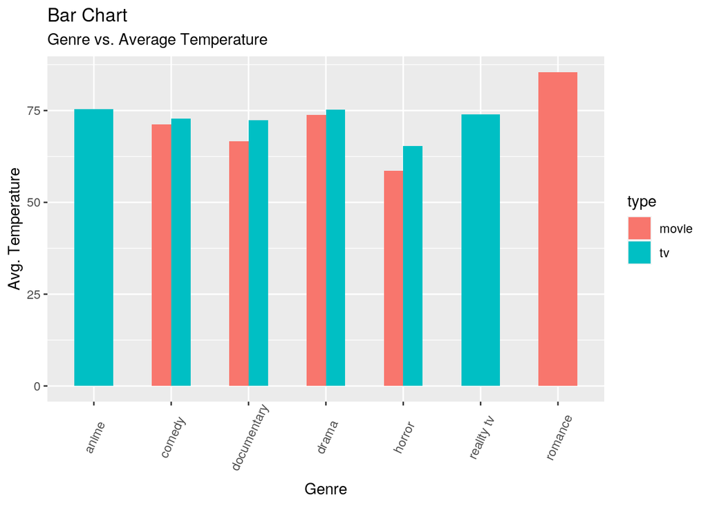

```r
# plot1
library(ggplot2)
ggplot(merged_data, aes(x = genre, y = temp_avg)) + geom_bar(aes(fill = type),
    stat = "summary", width = 0.5, position = "dodge") + labs(title = "Bar Chart",
    subtitle = "Genre vs. Average Temperature") + theme(axis.text.x = element_text(angle = 65,
    vjust = 0.6)) + ylab("Avg. Temperature") + xlab("Genre")
```

This bar chart demonstrates the average temperatures at which each genre was watched as well as what type. The genre that was watched at the lowest average temperatures was horror. The genre that was watched at the highest average temperatures was romance.

[figure not shown]

```r
## plot 2
library(ggplot2)
ggplot(merged_data, aes(genre, date, colour = type)) + geom_point() +
    stat_smooth(aes(group = type), method = "lm") + labs(title = "Precipitation vs. Genre") +
    theme(axis.text.x = element_text(angle = 50, vjust = 0.7)) +
    ylab("Precipitation") + xlab("Genre")
```

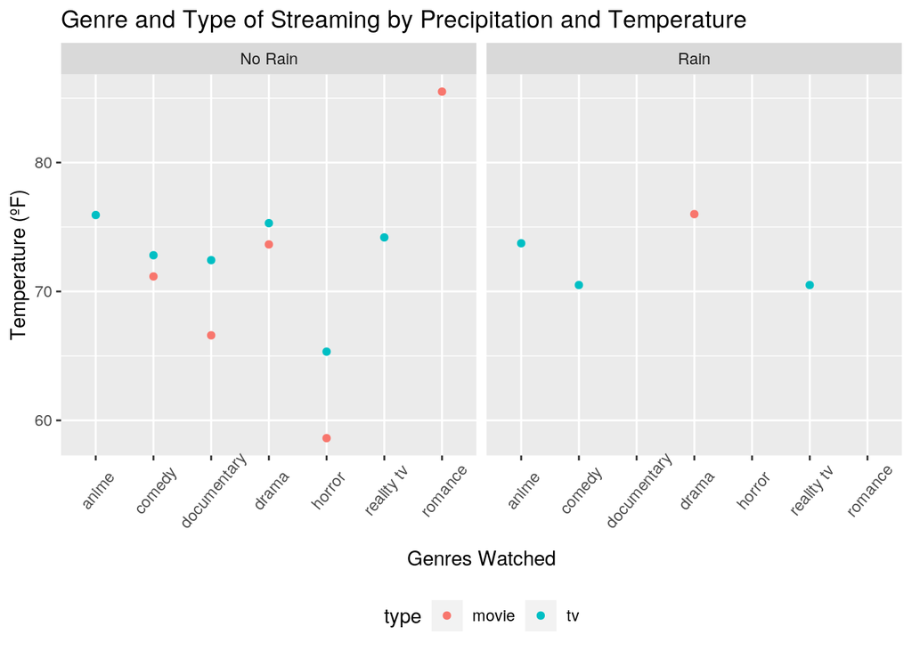

```r
# plot3
merged_data %>% mutate(rain = ifelse(precipitation > 1, "Rain",
    "No Rain")) %>% ggplot(aes(genre, temp_avg)) + geom_point(stat = "summary",
    fun = mean, aes(group = type, color = type)) + facet_wrap(~rain) +
    theme(legend.position = "bottom") + theme(axis.text.x = element_text(angle = 50,
    vjust = 0.7)) + labs(title = "Genre and Type of Streaming by Precipitation and Temperature",
    x = "Genres Watched", y = "Temperature (ºF)")
```

This scatter plot with a facet wrap is derived from a variable we created using mutate to differentiate the days in which it rained and which it did not. This plot indicated that on days that it rained, I watched anime, comedy, drama, and reality tv. I also watched more tv than movies when it rained. On the other hand, when it didn’t rain I watched moth movies and tv as well as every genre.

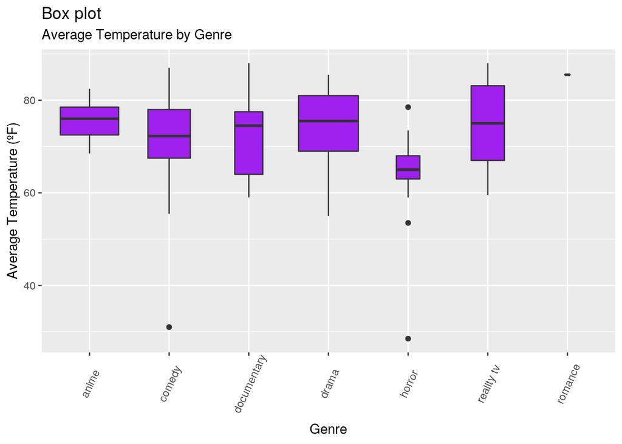

```r
# plot4
g <- ggplot(merged_data, aes(genre, temp_avg))
g + geom_boxplot(varwidth = T, fill = "purple") + theme(axis.text.x = element_text(angle = 65,
    vjust = 0.6)) + labs(title = "Box plot", subtitle = "Average Temperature by Genre",
    x = "Genre", y = "Average Temperature (ºF)")
```

#### Concluding Remarks

Through this project, I was challenged to test my knowledge of wrangling and data exploration. By using my own personal data, I was able to see patterns in the way I stream netflix in conjuction with the weather outside. It was very interesting! Thank you!